# Glioma - CTCF

Gloria Li

Apr, 4, 2017

Updated: Wed Aug 23 01:09:14 2017

## CTCF ChIP-seq processing

- FindER v0.9.3b enriched regions (no input bam files).
- For CTCF gain/loss sites: pairwaise between each IDHmut and each IDHwt samples and then take the intersect.
- No. of CTCF enriched regions:
  - retained between IDHwt and IDHmut: 35108
  - gain in IDHmut: 505
  - lost in IDHmut: 801

## Sequence motif comparison

- CTCF binding site motifs are slightly different for gain/loss sites and retained sites.

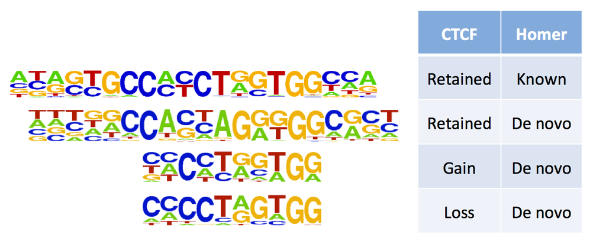

- Motifs around CTCF retained sites.

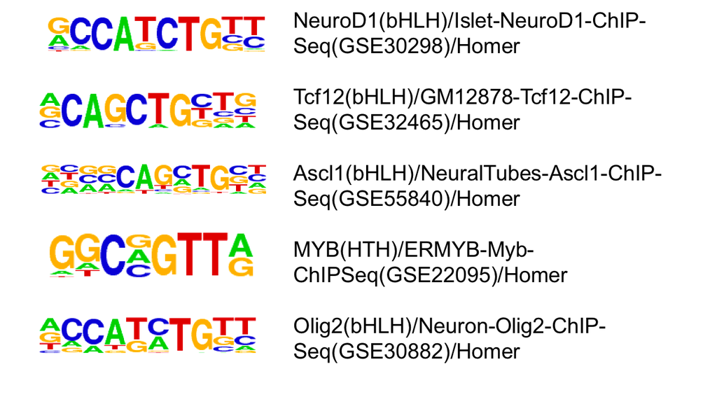

- Motifs around CTCF loss sites.

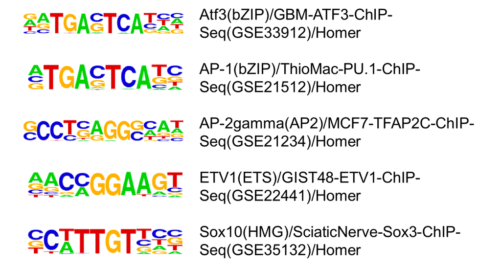

## DNA methylation changes at CTCF sites

- 5mC for CTCF binding sites +/- 20bp.
- There is significant gain of 5mC at CTCF loss regions in IDHmut gliomas.
- CTCF gain regions are methylated, slightly higher in IDHmut but not statistically significant.
- Retained CTCF binding sites are unmethylated.

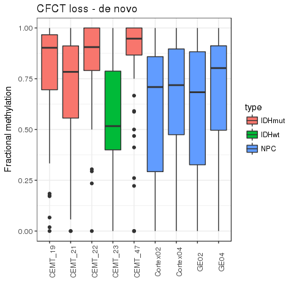

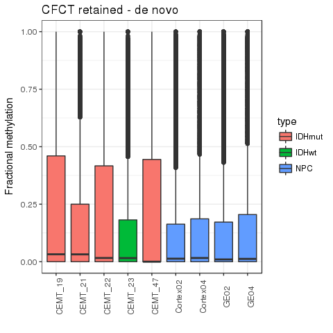

## H3K36me3 change at CTCF sites

- There is a slight gain of H3K36me3 at CTCF loss sites compared to retained/gain sites, coresponds to 5mC gain at these regions.

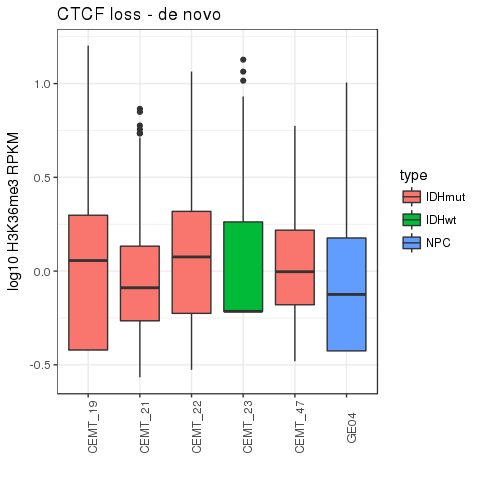

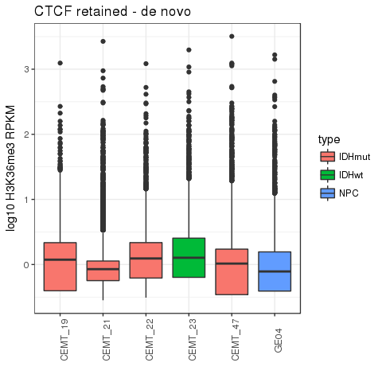

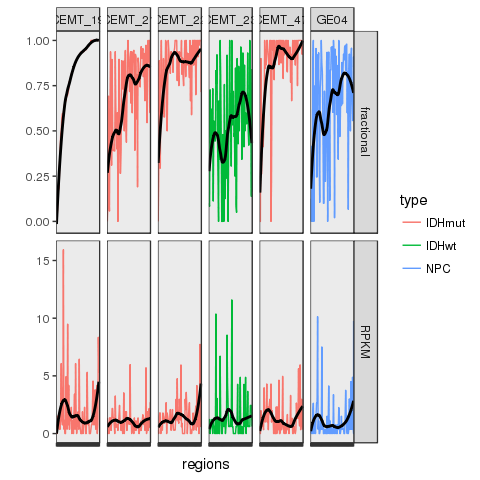

## RNAseq change at CTCF sites

- There is a slight gain of transcription at CTCF loss sites compared to retained/gain sites.

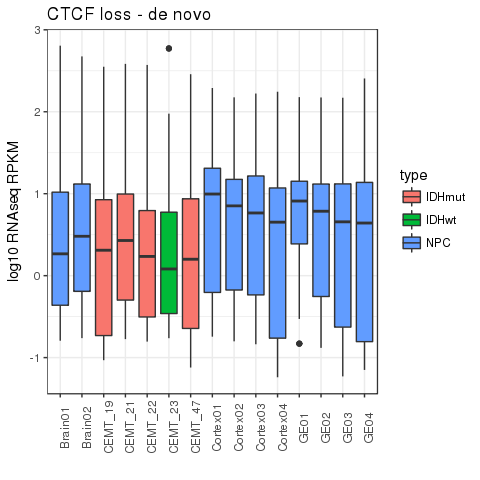

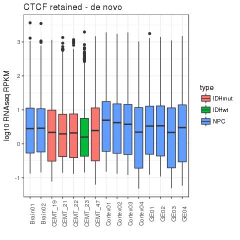

## Transcription deregulation associated with CTCF sites

- Identify genes with transcription deregulation associated with CTCF sites:
  - TSS and enhancer are on opposite sides of CTCF sites.
  - Distance between TSS and enhacner <= 50 kb.
  - RNA-seq RPKM change >= 2-fold.
- Genes higher expressed due to loss of CTCF sites unblocking enhancer.
  - SOX8: involved in determination of the cell fate and brain development and function.
  - GRID2IP: plays crucial roles in synaptogenesis and synaptic plasticity.
  - RAI1: involved in neuronal differentiation.
  - PROX1: plays a critical role in embryonic development and functions as a key regulatory protein in neurogenesis.
  - EFNB3: crucial for migration, repulsion and adhesion during neuronal, vascular and epithelial development.
  - CAMKK2: involved with learning and memory, neuronal differentiation and migration, neurite outgrowth, and synapse formation.
  - ZSCAN10: required to maintain ES cell pluripotency.
  - SMARCA4
  - LRP8: a key component of the Reelin pathway which governs neuronal layering of the forebrain during embryonic brain development.

| ENSG | Gene | CTCF | enhancer | d | IDHmut | CEMT_23 | logFC |
| --- | --- | --- | --- | --- | --- | --- | --- |
| ENSG00000162009 | SSTR5 | chr16:1080487-1080844 | chr16:1077787-1078246 | 44740.5 | 0.3040 | 0.0000 | 11.5702 |
| ENSG00000005513 | SOX8 | chr16:1080487-1080844 | chr16:1081613-1081916 | 49955.5 | 626.2690 | 4.1601 | 7.2340 |
| ENSG00000237847 | AL137798.1 | chr1:16979244-16979567 | chr1:16969622-16972250 | 28563.0 | 0.0102 | 0.0000 | 6.6833 |
| ENSG00000237847 | AL137798.1 | chr1:17022543-17022900 | chr1:17029992-17030354 | 30674.0 | 0.0102 | 0.0000 | 6.6833 |
| ENSG00000101489 | CELF4 | chr18:35133680-35133935 | chr18:35133925-35135164 | 11455.5 | 15.4591 | 0.3863 | 5.3221 |
| ENSG00000176383 | B3GNT4 | chr12:122667547-122667904 | chr12:122667534-122667933 | 20357.5 | 0.7139 | 0.0512 | 3.7978 |
| ENSG00000167363 | FN3K | chr17:80669693-80670033 | chr17:80656801-80657587 | 36258.0 | 30.3062 | 4.8238 | 2.6513 |
| ENSG00000215045 | GRID2IP | chr7:6565282-6565622 | chr7:6556058-6556753 | 34661.5 | 1.2839 | 0.2061 | 2.6388 |
| ENSG00000106976 | DNM1 | chr9:130978099-130978405 | chr9:130986891-130987217 | 21395.0 | 62.4635 | 11.3526 | 2.4600 |
| ENSG00000108557 | RAI1 | chr17:17604062-17604283 | chr17:17603765-17604091 | 19140.0 | 16.2355 | 3.2453 | 2.3227 |
| ENSG00000117707 | PROX1 | chr1:214176966-214177187 | chr1:214176589-214176981 | 20260.0 | 5.6837 | 1.2269 | 2.2117 |
| ENSG00000204387 | C6orf48 | chr6:31791718-31791922 | chr6:31791305-31791911 | 10778.0 | 283.8940 | 64.2056 | 2.1446 |
| ENSG00000141542 | RAB40B | chr17:80669693-80670033 | chr17:80673784-80675384 | 17980.0 | 9.7956 | 2.8048 | 1.8042 |
| ENSG00000127334 | DYRK2 | chr12:68076365-68076586 | chr12:68087561-68088105 | 45714.0 | 8.9901 | 2.7415 | 1.7133 |
| ENSG00000117533 | VAMP4 | chr1:171718429-171718837 | chr1:171723613-171723977 | 12408.0 | 30.4859 | 9.7683 | 1.6420 |
| ENSG00000204394 | VARS | chr6:31791718-31791922 | chr6:31793956-31795980 | 31238.0 | 43.1629 | 14.6962 | 1.5543 |
| ENSG00000125744 | RTN2 | chr19:45958940-45959280 | chr19:45954314-45954737 | 45793.5 | 6.7757 | 2.3829 | 1.5076 |
| ENSG00000108947 | EFNB3 | chr17:7633256-7633851 | chr17:7646731-7647063 | 38376.0 | 11.1475 | 4.0831 | 1.4490 |
| ENSG00000204396 | VWA7 | chr6:31791718-31791922 | chr6:31792649-31792975 | 47704.0 | 1.6515 | 0.6076 | 1.4425 |
| ENSG00000110931 | CAMKK2 | chr12:121714221-121714476 | chr12:121703256-121703582 | 32692.0 | 17.5805 | 6.5558 | 1.4231 |
| ENSG00000063587 | ZNF275 | chrX:152576361-152576684 | chrX:152576380-152576712 | 23068.0 | 30.0675 | 11.6917 | 1.3627 |
| ENSG00000136205 | TNS3 | chr7:47596023-47596227 | chr7:47575450-47575789 | 46536.5 | 23.8029 | 9.2865 | 1.3579 |
| ENSG00000130182 | ZSCAN10 | chr16:3155133-3155507 | chr16:3156037-3157045 | 7223.0 | 0.1525 | 0.0601 | 1.3415 |
| ENSG00000125386 | FAM193A | chr4:2594116-2594473 | chr4:2593065-2593391 | 33761.0 | 21.9528 | 8.8346 | 1.3132 |
| ENSG00000197965 | MPZL1 | chr1:167735754-167735992 | chr1:167737082-167737535 | 46878.5 | 77.3103 | 31.4231 | 1.2988 |
| ENSG00000127616 | SMARCA4 | chr19:11079428-11079649 | chr19:11086541-11087327 | 15335.0 | 30.0744 | 12.5121 | 1.2652 |
| ENSG00000132405 | TBC1D14 | chr4:6920650-6920922 | chr4:6926836-6927175 | 16035.5 | 44.9952 | 20.0278 | 1.1678 |
| ENSG00000169418 | NPR1 | chr1:153605694-153605966 | chr1:153605912-153607645 | 44335.5 | 2.6808 | 1.1999 | 1.1597 |
| ENSG00000148337 | CIZ1 | chr9:130978099-130978405 | chr9:130986891-130987217 | 20392.0 | 53.3708 | 24.2940 | 1.1354 |
| ENSG00000218328 | C1orf196 | chr1:14219090-14219362 | chr1:14219040-14219988 | 461.0 | 0.4550 | 0.2107 | 1.1105 |
| ENSG00000157193 | LRP8 | chr1:53817530-53817836 | chr1:53834400-53834702 | 40809.0 | 8.4128 | 3.9639 | 1.0856 |
| ENSG00000095370 | SH2D3C | chr9:130532155-130532393 | chr9:130515405-130518339 | 24148.0 | 7.9834 | 3.8926 | 1.0362 |

- Genes lower expressed due to gain of CTCF sites blocking enhancer.

| ENSG | Gene | CTCF | enhancer | d | IDHmut | CEMT_23 | logFC |
| --- | --- | --- | --- | --- | --- | --- | --- |
| ENSG00000183798 | EMILIN3 | chr20:39955730-39956104 | chr20:39945143-39946955 | 49418 | 0.0896 | 3.7966 | -5.4032 |
| ENSG00000183921 | SDR42E2 | chr16:22198975-22199264 | chr16:22201417-22201793 | 23322 | 0.0376 | 1.3076 | -5.1171 |
| ENSG00000118640 | VAMP8 | chr2:85771002-85771478 | chr2:85764623-85767481 | 22634 | 5.4663 | 140.6910 | -4.6858 |
| ENSG00000168899 | VAMP5 | chr2:85771002-85771478 | chr2:85764623-85767481 | 45480 | 13.7914 | 147.7100 | -3.4209 |
| ENSG00000171223 | JUNB | chr19:12891101-12891339 | chr19:12888025-12890499 | 13049 | 24.1761 | 136.3720 | -2.4959 |
| ENSG00000204174 | PPYR1 | chr10:47113359-47113614 | chr10:47116553-47116967 | 33225 | 0.0136 | 0.0743 | -2.4425 |
| ENSG00000166582 | CENPV | chr17:16261691-16262082 | chr17:16282177-16282553 | 25395 | 1.0349 | 5.5636 | -2.4264 |
| ENSG00000039987 | BEST2 | chr19:12891101-12891339 | chr19:12892627-12895297 | 31445 | 0.0175 | 0.0692 | -1.9734 |
| ENSG00000132793 | LPIN3 | chr20:39955730-39956104 | chr20:39945143-39946955 | 23512 | 0.1731 | 0.6631 | -1.9372 |
| ENSG00000104889 | RNASEH2A | chr19:12891101-12891339 | chr19:12888025-12890499 | 28133 | 11.5299 | 29.2786 | -1.3445 |